# 1. Introduction to Python programming

Module M-227-04: Programming for Data Analytics

Instructor: prof. Dmitry Pavlyuk

## About the Course

- Programming for Data Analytics
- **6 credit points** (9 ECTS): about 240 hours of studies (72 contact hours)
- The course is designed for major students with little or no programming experience and emphasizes writing programmes that can retrieve and manipulate a large amounts of data.
- Primary language - **Python**
- Learning-by-doing approach – weekly practices
- Assessment:
  - Independent project (50%)
  - Final practical exam on data processing (50%)

## Main topics

- Core Python
- Multidimensional computing (*NumPy* library)
- Data wrangling (*pandas* library)
- Data visualisation (*matplotlib* library)
- Modelling (*statsmodels*, *scikit-learn*)

## Materials

1. McKinney, W. (2022), Python for Data Analysis: Data Wrangling with pandas, NumPy, and Jupyter: https://wesmckinney.com/book/
2. Downey, A. (2016) Think Python: How to Think Like a Computer Scientist https://greenteapress.com/wp/think-python-2e/
3. Course demo notebooks https://github.com/DmitryPavlyuk/python-da

## What is Programming?

Computer programming is the process of designing and building an executable computer program (software).

Classes of software:

- Word/spreadsheet processing software
- Computer games
- Web applications
- Mobile applications
- **Data processing software**

# Python programming language

## Python: short history

- Released in 1991, Python 2.0 in 2000 (not supported now), Python 3.0 in 2008 – pretty old!
- TIOBE Popularity Index – Python is very popular now

[figure not shown]

Note the dynamics of Python popularity!

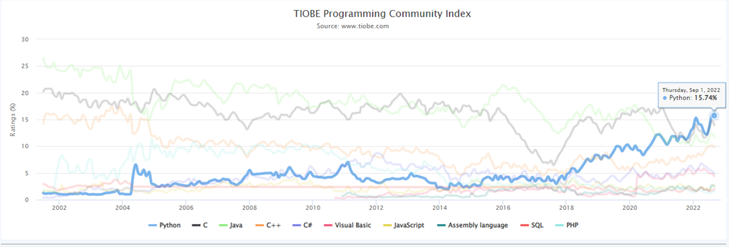

## Python and R

Python and R are the preferred languages in Data Science, Data Analysis, Machine Learning.

[figure not shown]

- Python is a general-purpose language (while R mainly is a statistical language), thus Python can be easier integrated in production environments
- Python is better suitable for machine learning, deep learning, and large-scale web applications.
- R is suitable for statistical learning having powerful libraries for data experiment and exploration.

## Types of programming languages

- **Low-level**: direct machine (computer) instructions
- **High-level**: computer-independent

#### Python is a high-level language

- **Declarative**: describe **what** the programme does
- **Imperative**: describe **how** the programme should work

#### Python is an imperative language

- **Domain-specific** (for particular application domain)
- **General-purpose**

#### Python is a general-purpose language

- **Compiled**: transform the commands to a lower-level programme
- **Interpreted**: translate every command and immediately execute it

#### Python is an interpreted language

## Programming environment

A software programme is a set of instructions that allow for a certain type of computer operation.

How to organise this set of instructions in Python:

- using **Command-line interface** (CLI) – send instructions as lines of text

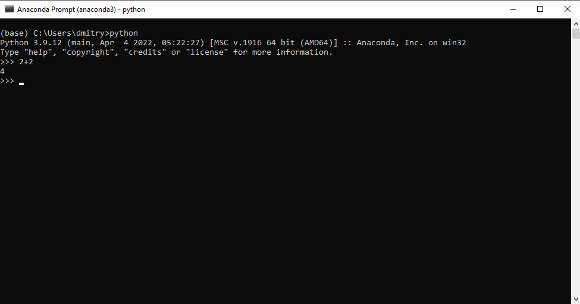

How to organise this set of instructions in Python:

- using **Scripts** – compose a file with instructions

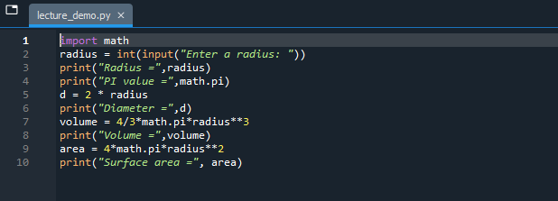

How to organise this set of instructions in Python:

- using **Notebooks** – interactively merge instructions, instructions’ results and text markdown

## Local environment

Anaconda is a distribution of the Python and R programming languages for scientific computing, that aims to simplify package management and deployment.

- Install Anaconda with the latest Python (currently 3.9) - https://www.anaconda.com/
  - Use Anaconda prompt from the Start menu to run “python” – the command line interface
  - Use “Jupyter Notebook” to start an interactive notebook editor
  - Use “Spyder” to start an environment for Python script editing

In this course we will mostly use Jupiter notebooks

## Cloud environment

- Register at Google Colab https://colab.research.google.com/ – a cloud environment for developing and running Python notebooks in your browser
- Optional: register at Github https://github.com/ for software cloud storage and version control

All my materials are available in Github https://github.com/DmitryPavlyuk/python-da (request access)

# First Python code

Calculate core characteristics of a ball with given radius

```python
radius = 5
```

#### Diameter:

$d=2r$

```python
d = 2 * radius
print(d)
```

```
10
```

## Value of $\pi$

Importing *math* module

```python
import math
```

```python
print(math.pi)
```

```
3.141592653589793
```

### Calculating ball characteristics

#### Volume:

$V=\frac{4}{3}\pi r^3$

```python
volume = 4/3*math.pi*radius**3
print(volume)
```

```
523.5987755982989
```

#### Surface area

$S = 4 \pi r^2$

```python
area = 4*math.pi*radius**2
print(area)
```

```
314.1592653589793
```